# 20212_M2.855_PEC3_Enunciado

# 2. Implementación del caso práctico (5 puntos)

Para este ejercicio se proporciona un *dataset* con datos sobre diferentes clientes de un banco que quieren comprar un piso, y si el banco les ha concedido la hipoteca o no.

La información es la siguiente:

- `ingresos`: los ingresos mensuales de la familia.
- `gastos_comunes`: pagos mensuales de luz, agua, gas, etc.
- `pago_coche`: si se está pagando cuota por uno o más coches, y los gastos mensuales en combustible, etc.
- `gastos_otros`: compra mensual en supermercado y lo necesario para vivir.
- `ahorros`: suma de ahorros dispuestos a utilizar para la compra de la casa.
- `vivienda`: precio de la vivienda que quiere comprar esta familia.
- `estado_civil`: 0-soltero, 1-casados, 2-divorciados
- `hijos`: cantidad de hijos menores y que no trabajan.
- `trabajo`: 0-sin empleo, 1-autónomo (freelance), 2-empleado, 3-empresario, 4-pareja: autónomos, 5-pareja: empleados, 6-pareja: autónomo y asalariado, 7-pareja: empresario y autónomo , 8-pareja: empresarios los dos o empresario y empleado
- `hipoteca`: 0-No ha sido concedida, 1-Si que ha sido concedida (esta será nuestra columna de salida, para aprender)

Empezamos leyendo el *dataset* y viendo una muestra de las primeras filas.

```python
hipotecas = pd.read_csv("hipotecas.csv")
hipotecas.head(10)
```

|  | ingresos | gastos_comunes | pago_coche | gastos_otros | ahorros | vivienda | estado_civil | hijos | trabajo | hipoteca |
| --- | --- | --- | --- | --- | --- | --- | --- | --- | --- | --- |
| 0 | 6000 | 1000 | 0 | 600 | 50000 | 400000 | 0 | 2 | 2 | 1 |
| 1 | 6745 | 944 | 123 | 429 | 43240 | 636897 | 1 | 3 | 6 | 0 |
| 2 | 6455 | 1033 | 98 | 795 | 57463 | 321779 | 2 | 1 | 8 | 1 |
| 3 | 7098 | 1278 | 15 | 254 | 54506 | 660933 | 0 | 0 | 3 | 0 |
| 4 | 6167 | 863 | 223 | 520 | 41512 | 348932 | 0 | 0 | 3 | 1 |
| 5 | 5692 | 911 | 11 | 325 | 50875 | 360863 | 1 | 4 | 5 | 1 |
| 6 | 6830 | 1298 | 345 | 309 | 46761 | 429812 | 1 | 1 | 5 | 1 |
| 7 | 6470 | 1035 | 39 | 782 | 57439 | 606291 | 0 | 0 | 1 | 0 |
| 8 | 6251 | 1250 | 209 | 571 | 50503 | 291010 | 0 | 0 | 3 | 1 |
| 9 | 6987 | 1258 | 252 | 245 | 40611 | 324098 | 2 | 1 | 7 | 1 |

### 2.1. Análisis descriptivo

Cuando se nos proporciona un *dataset*, antes de empezar a hacer nada, es muy importante hacer un análisis exploratorio para conocer los datos con los que trabajaremos.

**Implementación:** Calculad las frecuencias de la variable _target_ (`hipoteca`). Analizar la distribución de las otras variables con gráficos de barras las variables categóricas y con histogramas las variables numéricas.

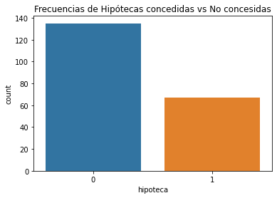

```python
ax = sns.countplot(x="hipoteca", data=hipotecas).set(title='Frecuencias de Hipótecas concedidas vs No concesidas')
```

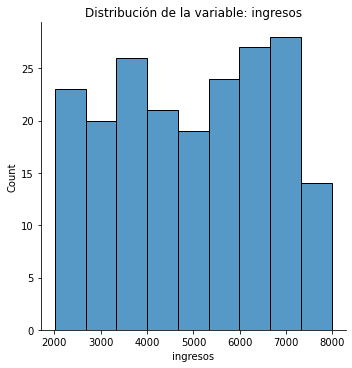

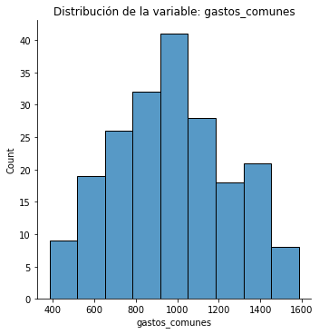

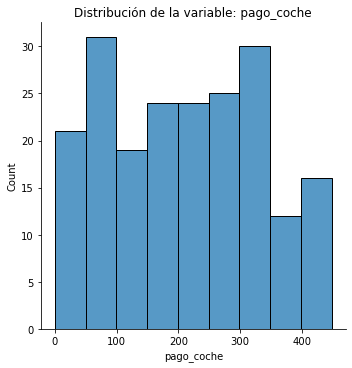

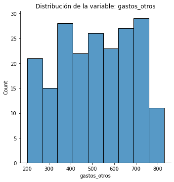

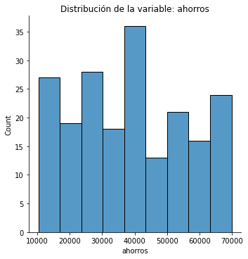

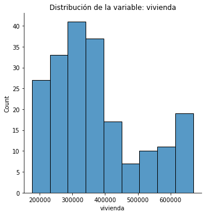

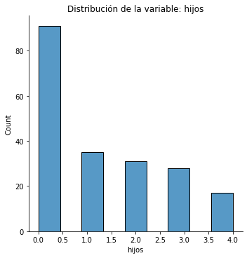

```python
numericFeatures = ["ingresos","gastos_comunes","pago_coche","gastos_otros","ahorros","vivienda","hijos"]

for i in numericFeatures:
    print("")
    sns.displot(hipotecas, x = str(i)).set(title='Distribución de la variable: {}'.format(str(i)))
    plt.show()
```

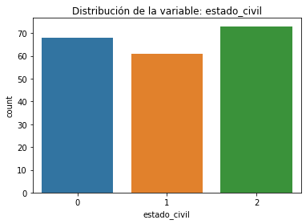

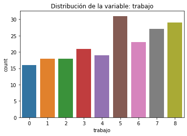

```python
categoricalFeatures = ["estado_civil","trabajo"]

for i in categoricalFeatures:
    print("")
    ax = sns.countplot(x=str(i), data=hipotecas).set(title='Distribución de la variable: {}'.format(str(i)))
    plt.show()
```

```python
pd.set_option('display.max_rows', 500)
```

La media de los ingresos es mayor en el grupo de personas a las que le he es concedida la hipóteca

```python
hipotecas[["ingresos","gastos_comunes",
           "pago_coche","gastos_otros",
           "ahorros","vivienda", "hipoteca"]].groupby("hipoteca").describe().T
```

|  | hipoteca | 0 | 1 |
| --- | --- | --- | --- |
| ingresos | count | 135.000000 | 67.000000 |
|  | mean | 4406.570370 | 6072.089552 |
|  | std | 1646.043268 | 1114.368251 |
|  | min | 2008.000000 | 3382.000000 |
|  | 25% | 3082.000000 | 5441.500000 |
|  | 50% | 4054.000000 | 6139.000000 |
|  | 75% | 5760.500000 | 6946.500000 |
|  | max | 7831.000000 | 7984.000000 |
| gastos_comunes | count | 135.000000 | 67.000000 |
|  | mean | 933.303704 | 1048.716418 |
|  | std | 284.720137 | 227.742332 |
|  | min | 384.000000 | 615.000000 |
|  | 25% | 690.000000 | 889.500000 |
|  | 50% | 941.000000 | 999.000000 |
|  | 75% | 1129.500000 | 1260.000000 |
|  | max | 1502.000000 | 1585.000000 |
| pago_coche | count | 135.000000 | 67.000000 |
|  | mean | 228.992593 | 176.985075 |
|  | std | 129.362357 | 108.299318 |
|  | min | 2.000000 | 0.000000 |
|  | 25% | 107.000000 | 86.500000 |
|  | 50% | 234.000000 | 181.000000 |
|  | 75% | 338.500000 | 260.000000 |
|  | max | 448.000000 | 419.000000 |
| gastos_otros | count | 135.000000 | 67.000000 |
|  | mean | 528.459259 | 489.164179 |
|  | std | 159.432471 | 182.770729 |
|  | min | 201.000000 | 209.000000 |
|  | 25% | 398.000000 | 334.500000 |
|  | 50% | 527.000000 | 510.000000 |
|  | 75% | 663.000000 | 632.000000 |
|  | max | 818.000000 | 828.000000 |
| ahorros | count | 135.000000 | 67.000000 |
|  | mean | 34591.088889 | 47128.895522 |
|  | std | 17219.801104 | 14480.442091 |
|  | min | 10319.000000 | 11116.000000 |
|  | 25% | 19552.500000 | 40265.000000 |
|  | 50% | 32444.000000 | 49221.000000 |
|  | 75% | 43906.500000 | 57435.500000 |
|  | max | 69366.000000 | 69934.000000 |
| vivienda | count | 135.000000 | 67.000000 |
|  | mean | 387350.096296 | 345139.761194 |
|  | std | 151588.067724 | 93669.097351 |
|  | min | 176553.000000 | 182365.000000 |
|  | 25% | 266638.000000 | 285258.500000 |
|  | 50% | 350589.000000 | 333566.000000 |
|  | 75% | 529309.500000 | 396616.000000 |
|  | max | 669540.000000 | 619056.000000 |

### 2.2. Preprocesamiento de los datos

Una vez hecho un primer análisis, se trata de "limpiar" el dataset y adaptarlo a nuestras necesidades (en este caso, predecir si se concederá la hipoteca o no).

**Implementación:** Comprueba si hay valores `null`. En caso de haberlos, elimina las filas correspondientes.

```python
hipotecas.info()
```

```
<class 'pandas.core.frame.DataFrame'>
RangeIndex: 202 entries, 0 to 201
Data columns (total 10 columns):
 #   Column          Non-Null Count  Dtype
---  ------          --------------  -----
 0   ingresos        202 non-null    int64
 1   gastos_comunes  202 non-null    int64
 2   pago_coche      202 non-null    int64
 3   gastos_otros    202 non-null    int64
 4   ahorros         202 non-null    int64
 5   vivienda        202 non-null    int64
 6   estado_civil    202 non-null    int64
 7   hijos           202 non-null    int64
 8   trabajo         202 non-null    int64
 9   hipoteca        202 non-null    int64
dtypes: int64(10)
memory usage: 15.9 KB
```

No se observan valores nulos

**Implementación:** - Agrupad los diversos gastos mensuales (`pago_coche` + `gastos_comunes` + `gastos_otros`) en una variable llamada `gastos`. - Calculad el montante a financiar en una variable llamada `financiar`. Para ello crea una columna llamada `financiar` que será el resto del precio de la vivienda con los ahorros de la familia. - Elimina las variables utilizadas para crear estas nuevas columnas.

```python
hipotecas["gastos"] = hipotecas["pago_coche"] + hipotecas["gastos_comunes"] + hipotecas["gastos_otros"]

hipotecas = hipotecas[["ingresos", "gastos", "ahorros",
                       "vivienda", "estado_civil","hijos",
                       "trabajo", "hipoteca"]]
```

```python
hipotecas.head()
```

|  | ingresos | gastos | ahorros | vivienda | estado_civil | hijos | trabajo | hipoteca |
| --- | --- | --- | --- | --- | --- | --- | --- | --- |
| 0 | 6000 | 1600 | 50000 | 400000 | 0 | 2 | 2 | 1 |
| 1 | 6745 | 1496 | 43240 | 636897 | 1 | 3 | 6 | 0 |
| 2 | 6455 | 1926 | 57463 | 321779 | 2 | 1 | 8 | 1 |
| 3 | 7098 | 1547 | 54506 | 660933 | 0 | 0 | 3 | 0 |
| 4 | 6167 | 1606 | 41512 | 348932 | 0 | 0 | 3 | 1 |

```python
hipotecas["financiar"] = hipotecas["vivienda"] - hipotecas["ahorros"]
hipotecas = hipotecas[["ingresos", "gastos", "financiar", "hijos", "estado_civil","trabajo", "hipoteca"]]
hipotecas.sample(2)
```

|  | ingresos | gastos | financiar | hijos | estado_civil | trabajo | hipoteca |
| --- | --- | --- | --- | --- | --- | --- | --- |
| 64 | 2138 | 1294 | 384688 | 0 | 0 | 1 | 0 |
| 8 | 6251 | 2030 | 240507 | 0 | 0 | 3 | 1 |

El siguiente paso sería ver la correlación entre todas las *features* numéricas. Esto se hace para asegurar que no hay dos variables muy relacionadas entre sí, ya que en tal caso se debería seleccionar una de las dos o combinarlas en una nueva.

```python
hipotecas[["ingresos", "gastos", "financiar", "hijos"]].corr()
```

|  | ingresos | gastos | financiar | hijos |
| --- | --- | --- | --- | --- |
| ingresos | 1.000000 | 0.362823 | 0.564351 | -0.024483 |
| gastos | 0.362823 | 1.000000 | 0.105849 | -0.013228 |
| financiar | 0.564351 | 0.105849 | 1.000000 | -0.153068 |
| hijos | -0.024483 | -0.013228 | -0.153068 | 1.000000 |

**Implementación:** Mostrad la correlación entre todas las _features_ numéricas. Si hay dos con una correlación superior al 80%, eliminar una de las dos. Podéis utilizar `heatmap` de `Seaborn`, para verlas en un mapa de colores.

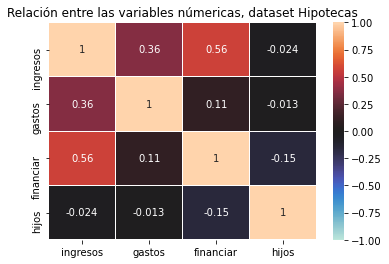

```python
sns.heatmap(hipotecas[["ingresos", "gastos", "financiar", "hijos"]].corr(),
            vmin=-1, vmax=1, center=0,annot=True, linewidths=.01
           ).set(title='Relación entre las variables númericas, dataset Hipotecas')
plt.show()
```

No hay correlaciones superiores 0.80 entre los predictores

Ya tenemos las variables finales con las que trabajaremos. Vamos a observar ahora cuál es la relación de cada una de ellas con el `target`.

**Implementación:** Repite los diagramas de barras y los histogramas, separando por colores la variable _target_ (dentro del mismo gráfico, diferenciar entre hipoteca-sí y hipoteca-no). Nota: Puedes utilizar el parámetro `alpha` para que se vean los dos gráficos a la vez.

```python
hipotecas.head(2)
```

|  | ingresos | gastos | financiar | hijos | estado_civil | trabajo | hipoteca |
| --- | --- | --- | --- | --- | --- | --- | --- |
| 0 | 6000 | 1600 | 350000 | 2 | 0 | 2 | 1 |
| 1 | 6745 | 1496 | 593657 | 3 | 1 | 6 | 0 |

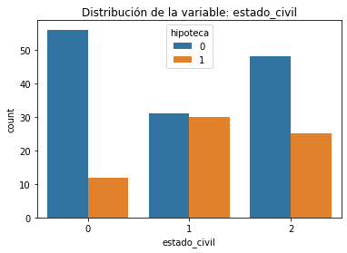

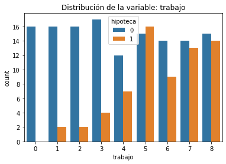

```python
for i in categoricalFeatures:
    print("")
    ax = sns.countplot(x=str(i), data=hipotecas, hue="hipoteca").set(title='Distribución de la variable: {}'.format(str(i)))
    plt.show()
```

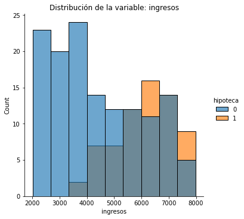

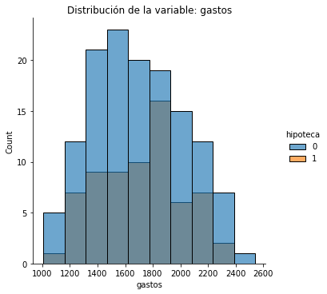

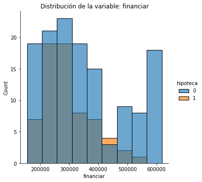

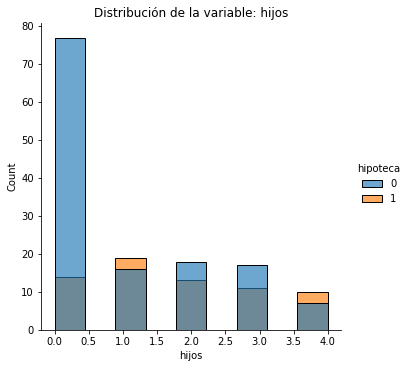

```python
numericFeatures = ["ingresos","gastos","financiar","hijos"]

for i in numericFeatures:
    print("")
    sns.displot(hipotecas, x = str(i), hue = "hipoteca", alpha = 0.65).set(title='Distribución de la variable: {}'.format(str(i)))
    plt.show()
```